# Tècniques Avançades en Mineria de Dades. Pràctica 2

Víctor Rubert Alfonso

Francesc Xavier Gayà Morey

# Introducció

En el problema de classificació, molts cops es pot trobar en què les dades no tenen una simetria en quant a la quantitat de dades amb valors positius o negatius. Quan el conjunt de dades té unes característiques d’aquest estil es diu que és un problema de balanceig. Exemples d’aquest estil poden sortir en camps tan diversos com la medicina, on la majoria de vegades el pacient no té la malaltia, o en criminologia, on molts de cops pot passar que el sospitòs sigui innocent.

Per resoldre aquest problema existeixen diverses tècniques que minimitzen els efectes d’aquest balanceig, i en aquest treball s’intentaran aplicar una mostra d’aquestes i comparar els seus resultats.

Les dades utilitzades són un conjunt de dades relacionades amb el frau en transaccions bancàries. En aquest cas, la majoria de les dades són transaccions no fraudulentes, però n’hi ha unes poques que s’han detectat com a frau, i es preté, a partir de les dades que es tenen, intentar detectar quan s’ha comés el crim.

## Preparació del DataFrame

Importar llibreries:

```r
library(unbalanced)
library(caret)
library(rpart) # Arbre de decisió
library(class) # KNN
library(e1071) # SVM
library(corrplot)
```

### Lectura del CSV

Llegir el CSV amb la informació de targetes de crèdit. A més, convertim a numèric tots els valors de les diferents variables, i en factors els valors de la classe que volem predir:

```r
credit.card = read.csv2("creditcard.csv", header = TRUE, sep = ",")

# Convertir a dades numèriques
for (i in 1:(ncol(credit.card)-1)){
  credit.card[[i]] = as.numeric(credit.card[[i]])
}
credit.card$Class = factor(credit.card$Class, levels = c(0, 1))
```

### Anàlisi exploratori de les variables

```r
str(credit.card)
```

```
'data.frame':   284807 obs. of  31 variables:
 $ Time  : num  0 0 1 1 2 2 4 7 7 9 ...
 $ V1    : num  -1.36 1.192 -1.358 -0.966 -1.158 ...
 $ V2    : num  -0.0728 0.2662 -1.3402 -0.1852 0.8777 ...
 $ V3    : num  2.536 0.166 1.773 1.793 1.549 ...
 $ V4    : num  1.378 0.448 0.38 -0.863 0.403 ...
 $ V5    : num  -0.3383 0.06 -0.5032 -0.0103 -0.4072 ...
 $ V6    : num  0.4624 -0.0824 1.8005 1.2472 0.0959 ...
 $ V7    : num  0.2396 -0.0788 0.7915 0.2376 0.5929 ...
 $ V8    : num  0.0987 0.0851 0.2477 0.3774 -0.2705 ...
 $ V9    : num  0.364 -0.255 -1.515 -1.387 0.818 ...
 $ V10   : num  0.0908 -0.167 0.2076 -0.055 0.7531 ...
 $ V11   : num  -0.552 1.613 0.625 -0.226 -0.823 ...
 $ V12   : num  -0.6178 1.0652 0.0661 0.1782 0.5382 ...
 $ V13   : num  -0.991 0.489 0.717 0.508 1.346 ...
```

[output cut: 17 more lines]

```r
head(credit.card)
```

|  | Time | V1 | V2 | V3 | V4 | V5 | V6 | V7 | V8 | V9 | V10 | V11 | V12 | V13 | V14 | V15 | V16 | V17 | V18 | V19 | V20 | V21 | V22 | V23 | V24 | V25 | V26 | V27 | V28 | … |
| --- | --- | --- | --- | --- | --- | --- | --- | --- | --- | --- | --- | --- | --- | --- | --- | --- | --- | --- | --- | --- | --- | --- | --- | --- | --- | --- | --- | --- | --- | --- |
| 1 | 0 | -1.3598071 | -0.07278117 | 2.5363467 | 1.3781552 | -0.33832077 | 0.46238778 | 0.23959855 | 0.09869790 | 0.3637870 | 0.09079417 | -0.5515995 | -0.61780086 | -0.9913898 | -0.3111694 | 1.4681770 | -0.4704005 | 0.20797124 | 0.02579058 | 0.40399296 | 0.25141210 | -0.018306778 | 0.277837576 | -0.11047391 | 0.06692807 | 0.1285394 | -0.1891148 | 0.133558377 | -0.02105305 | … |
| 2 | 0 | 1.1918571 | 0.26615071 | 0.1664801 | 0.4481541 | 0.06001765 | -0.08236081 | -0.07880298 | 0.08510165 | -0.2554251 | -0.16697441 | 1.6127267 | 1.06523531 | 0.4890950 | -0.1437723 | 0.6355581 | 0.4639170 | -0.11480466 | -0.18336127 | -0.14578304 | -0.06908314 | -0.225775248 | -0.638671953 | 0.10128802 | -0.33984648 | 0.1671704 | 0.1258945 | -0.008983099 | 0.01472417 | … |
| 3 | 1 | -1.3583541 | -1.34016307 | 1.7732093 | 0.3797796 | -0.50319813 | 1.80049938 | 0.79146096 | 0.24767579 | -1.5146543 | 0.20764287 | 0.6245015 | 0.06608369 | 0.7172927 | -0.1659459 | 2.3458649 | -2.8900832 | 1.10996938 | -0.12135931 | -2.26185710 | 0.52497973 | 0.247998153 | 0.771679402 | 0.90941226 | -0.68928096 | -0.3276418 | -0.1390966 | -0.055352794 | -0.05975184 | … |
| 4 | 1 | -0.9662717 | -0.18522601 | 1.7929933 | -0.8632913 | -0.01030888 | 1.24720317 | 0.23760894 | 0.37743587 | -1.3870241 | -0.05495192 | -0.2264873 | 0.17822823 | 0.5077569 | -0.2879237 | -0.6314181 | -1.0596472 | -0.68409279 | 1.96577500 | -1.23262197 | -0.20803778 | -0.108300452 | 0.005273597 | -0.19032052 | -1.17557533 | 0.6473760 | -0.2219288 | 0.062722849 | 0.06145763 | … |
| 5 | 2 | -1.1582331 | 0.87773675 | 1.5487178 | 0.4030339 | -0.40719338 | 0.09592146 | 0.59294075 | -0.27053268 | 0.8177393 | 0.75307443 | -0.8228429 | 0.53819555 | 1.3458516 | -1.1196698 | 0.1751211 | -0.4514492 | -0.23703324 | -0.03819479 | 0.80348692 | 0.40854236 | -0.009430697 | 0.798278495 | -0.13745808 | 0.14126698 | -0.2060096 | 0.5022922 | 0.219422230 | 0.21515315 | … |
| 6 | 2 | -0.4259659 | 0.96052304 | 1.1411093 | -0.1682521 | 0.42098688 | -0.02972755 | 0.47620095 | 0.26031433 | -0.5686714 | -0.37140720 | 1.3412620 | 0.35989384 | -0.3580907 | -0.1371337 | 0.5176168 | 0.4017259 | -0.05813282 | 0.06865315 | -0.03319379 | 0.08496767 | -0.208253515 | -0.559824796 | -0.02639767 | -0.37142658 | -0.2327938 | 0.1059148 | 0.253844225 | 0.08108026 | … |

Veim com tenim diferents variables amb noms genèrics per respectar l’anonimitat de les dades. També es pot veure que aquestes dades agafen valors al voltant del 0.

#### Desbalanç de les classes

Una de les parts més importants a tractar en aquest treball és el fet de no tenir una quantitat similar de dades positives que negatives. Feim una ullada a la quantitat de cadascuna d’aquestes classes:

```r
n_classes = table(credit.card$Class)
print(paste("Classe 0:", n_classes[[1]], "(", round(n_classes[[1]]*100/sum(n_classes), 3), "%)"))
```

```
[1] "Classe 0: 284315 ( 99.827 %)"
```

```r
print(paste("Classe 1:", n_classes[[2]], "(", round(n_classes[[2]]*100/sum(n_classes), 3), "%)"))
```

```
[1] "Classe 1: 492 ( 0.173 %)"
```

Veim com efectivament la classe negativa, o classe 0, representa un gran percentatge de les dades que tenim, i per tant el problema de classificació és clarament un problema de desbalanceig.\

Continuant amb l’anàlisis de les variables, veurem a continuació diversos histogrames d’algunes variables.

#### Columna de temps

Començam aquesta visualització amb una de les poques variables que coneixem, que és el temps transcorregut desde la primera transacció enregistrada.

```r
summary(credit.card$Time)
```

```
   Min. 1st Qu.  Median    Mean 3rd Qu.    Max.
      0   54202   84692   94814  139321  172792
```

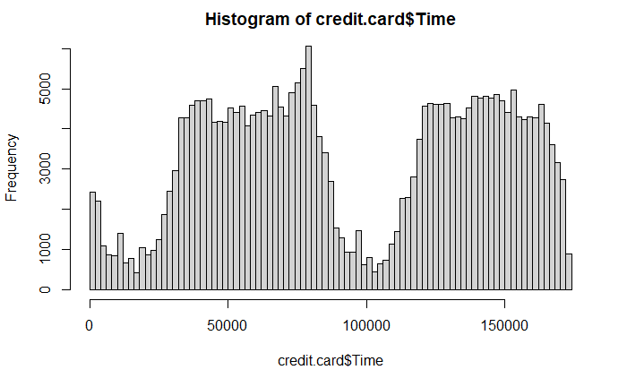

```r
hist(credit.card$Time, breaks = 100)
```

Podem veure com el volum de transaccions és més elevat en dos moment de tot el periode enregistrat. Aquestes dues parts són degudes als dos dies que es tenen presents. Si bé en cap moment no tenim una quantitat nul·la de transaccions, si que podem veure una baixada significativa a les hores nocturnes.

#### Columna de quantitat

Vegem ara un histograma de les quantitats deixades:

```r
summary(credit.card$Amount)
```

```
    Min.  1st Qu.   Median     Mean  3rd Qu.     Max.
    0.00     5.60    22.00    88.35    77.17 25691.16
```

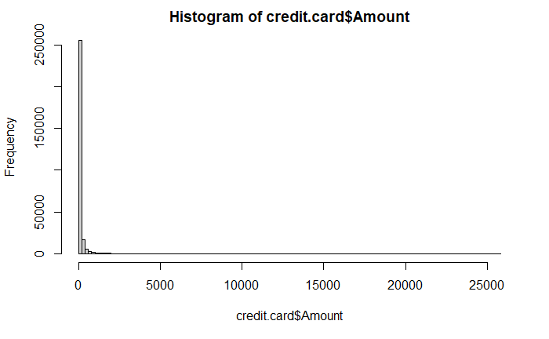

```r
hist(credit.card$Amount, breaks = 100)
```

Veim com la majoria dels prèstecs concebuts estan situats a la part esquerra del diagrama, que son aquelles quantitats no superiors a 100€.

#### Resta de columnes

Per la resta de columnes, com que no sabem què representen, no podem extreure conclusions tan axhaustives. Si que podem, encara així, calcular alguns estadístics sobre aquestes.

```r
summary(credit.card[,2:29])
```

```
       V1                  V2                  V3                 V4                 V5                   V6                 V7                 V8
 Min.   :-56.40751   Min.   :-72.71573   Min.   :-48.3256   Min.   :-5.68317   Min.   :-113.74331   Min.   :-26.1605   Min.   :-43.5572   Min.   :-73.21672
 1st Qu.: -0.92037   1st Qu.: -0.59855   1st Qu.: -0.8904   1st Qu.:-0.84864   1st Qu.:  -0.69160   1st Qu.: -0.7683   1st Qu.: -0.5541   1st Qu.: -0.20863
 Median :  0.01811   Median :  0.06549   Median :  0.1799   Median :-0.01985   Median :  -0.05434   Median : -0.2742   Median :  0.0401   Median :  0.02236
 Mean   :  0.00000   Mean   :  0.00000   Mean   :  0.0000   Mean   : 0.00000   Mean   :   0.00000   Mean   :  0.0000   Mean   :  0.0000   Mean   :  0.00000
 3rd Qu.:  1.31564   3rd Qu.:  0.80372   3rd Qu.:  1.0272   3rd Qu.: 0.74334   3rd Qu.:   0.61193   3rd Qu.:  0.3986   3rd Qu.:  0.5704   3rd Qu.:  0.32735
 Max.   :  2.45493   Max.   : 22.05773   Max.   :  9.3826   Max.   :16.87534   Max.   :  34.80167   Max.   : 73.3016   Max.   :120.5895   Max.   : 20.00721
       V9                 V10                 V11                V12                V13                V14                V15                V16
 Min.   :-13.43407   Min.   :-24.58826   Min.   :-4.79747   Min.   :-18.6837   Min.   :-5.79188   Min.   :-19.2143   Min.   :-4.49894   Min.   :-14.12985
 1st Qu.: -0.64310   1st Qu.: -0.53543   1st Qu.:-0.76249   1st Qu.: -0.4056   1st Qu.:-0.64854   1st Qu.: -0.4256   1st Qu.:-0.58288   1st Qu.: -0.46804
 Median : -0.05143   Median : -0.09292   Median :-0.03276   Median :  0.1400   Median :-0.01357   Median :  0.0506   Median : 0.04807   Median :  0.06641
 Mean   :  0.00000   Mean   :  0.00000   Mean   : 0.00000   Mean   :  0.0000   Mean   : 0.00000   Mean   :  0.0000   Mean   : 0.00000   Mean   :  0.00000
 3rd Qu.:  0.59714   3rd Qu.:  0.45392   3rd Qu.: 0.73959   3rd Qu.:  0.6182   3rd Qu.: 0.66251   3rd Qu.:  0.4931   3rd Qu.: 0.64882   3rd Qu.:  0.52330
 Max.   : 15.59500   Max.   : 23.74514   Max.   :12.01891   Max.   :  7.8484   Max.   : 7.12688   Max.   : 10.5268   Max.   : 8.87774   Max.   : 17.31511
      V17                 V18                 V19                 V20                 V21                 V22                  V23                 V24
 Min.   :-25.16280   Min.   :-9.498746   Min.   :-7.213527   Min.   :-54.49772   Min.   :-34.83038   Min.   :-10.933144   Min.   :-44.80774   Min.   :-2.83663
 1st Qu.: -0.48375   1st Qu.:-0.498850   1st Qu.:-0.456299   1st Qu.: -0.21172   1st Qu.: -0.22839   1st Qu.: -0.542350   1st Qu.: -0.16185   1st Qu.:-0.35459
 Median : -0.06568   Median :-0.003636   Median : 0.003735   Median : -0.06248   Median : -0.02945   Median :  0.006782   Median : -0.01119   Median : 0.04098
 Mean   :  0.00000   Mean   : 0.000000   Mean   : 0.000000   Mean   :  0.00000   Mean   :  0.00000   Mean   :  0.000000   Mean   :  0.00000   Mean   : 0.00000
 3rd Qu.:  0.39968   3rd Qu.: 0.500807   3rd Qu.: 0.458949   3rd Qu.:  0.13304   3rd Qu.:  0.18638   3rd Qu.:  0.528554   3rd Qu.:  0.14764   3rd Qu.: 0.43953
 Max.   :  9.25353   Max.   : 5.041069   Max.   : 5.591971   Max.   : 39.42090   Max.   : 27.20284   Max.   : 10.503090   Max.   : 22.52841   Max.   : 4.58455
      V25                 V26                V27                  V28
 Min.   :-10.29540   Min.   :-2.60455   Min.   :-22.565679   Min.   :-15.43008
 1st Qu.: -0.31715   1st Qu.:-0.32698   1st Qu.: -0.070840   1st Qu.: -0.05296
 Median :  0.01659   Median :-0.05214   Median :  0.001342   Median :  0.01124
 Mean   :  0.00000   Mean   : 0.00000   Mean   :  0.000000   Mean   :  0.00000
 3rd Qu.:  0.35072   3rd Qu.: 0.24095   3rd Qu.:  0.091045   3rd Qu.:  0.07828
 Max.   :  7.51959   Max.   : 3.51735   Max.   : 31.612198   Max.   : 33.84781
```

Veim com no sols totes tenen valors propers al 0 sino que a més aquesta és la mitjana de cada variable.

Histograma de dues variables a mode d’exemple:

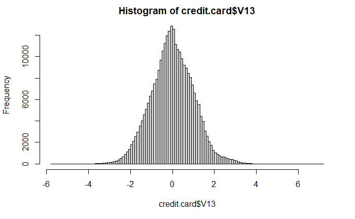

```r
hist(credit.card$V13, breaks = 100)
```

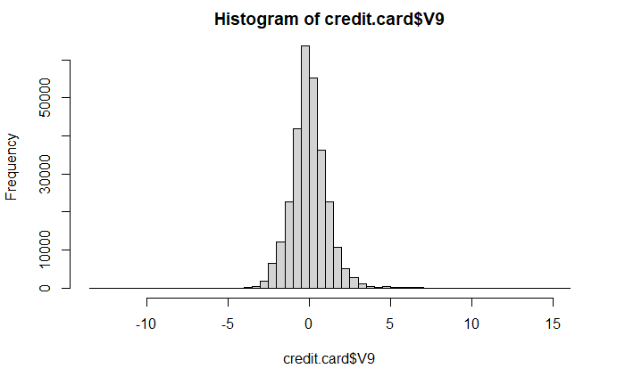

```r
hist(credit.card$V9, breaks = 100)
```

Veim com, a més, gràficament les diferents variables segueixen una distribució normal.

#### Correlació entre variables

A continuació, es representa la correlació trobada entre variables. El valor més elevat el trobam entre les variables “Amount” i V2: -0,53:

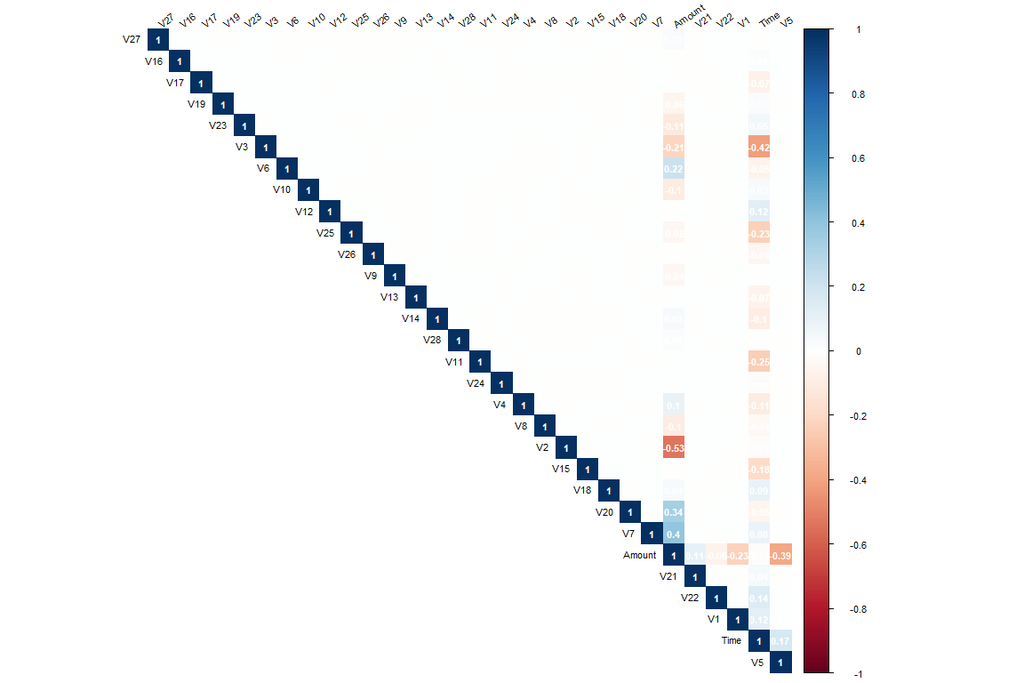

```r
corrplot(cor(credit.card[, -ncol(credit.card)]),
                   method = "color",
                   type = "upper",
                   addCoef.col = "white",number.cex = 0.7,
                   tl.col="black", tl.srt=35,tl.cex = 0.7,
                   cl.cex = 0.7,order = "hclust")
```

Així, vegent que en general la correlació es prou baixa, consideram que no és necessari eliminar cap variable. En el cas que s’hagués trobat una alta correlació entre variables, si que hagués estat adient eliminar-ne alguna, ja que significaria que la major part de la informació que aporta una variable, pot esser explicada ja per una altra

### Normalització de les dades

Abans de procedir, és important normalitzar les dades, ja que s’hauran d’entrenar models d’aprenentatge automàtic i, com hem vist, els valors que poden prendre les diferents variables són molt diferents (la variable de temps, sobretot, pot prendre valors molt elevats).

Per fer la normalització de les dades, senzillament s’han deixat amb valor mínim de 0 i màxim de 1, reescalant totes les dades a aquest intérval:

```r
scl <- function(x){ (x - min(x))/(max(x) - min(x)) }
credit.norm = credit.card
credit.norm[, -ncol(credit.norm)] = data.frame(lapply(credit.card[, -ncol(credit.card)], scl))
head(credit.norm)
```

|  | Time | V1 | V2 | V3 | V4 | V5 | V6 | V7 | V8 | V9 | V10 | V11 | V12 | V13 | V14 | V15 | V16 | V17 | V18 | V19 | V20 | V21 | V22 | V23 | V24 | V25 | V26 | V27 | V28 | … |
| --- | --- | --- | --- | --- | --- | --- | --- | --- | --- | --- | --- | --- | --- | --- | --- | --- | --- | --- | --- | --- | --- | --- | --- | --- | --- | --- | --- | --- | --- | --- |
| 1 | 0.000000e+00 | 0.9351923 | 0.7664904 | 0.8813649 | 0.3130227 | 0.7634387 | 0.2676686 | 0.2668152 | 0.7864442 | 0.4753117 | 0.5106005 | 0.2524843 | 0.6809076 | 0.3715906 | 0.6355905 | 0.4460837 | 0.4343924 | 0.7371726 | 0.6550659 | 0.5948632 | 0.5829422 | 0.5611844 | 0.5229921 | 0.6637930 | 0.3912527 | 0.5851218 | 0.3945568 | 0.4189761 | 0.3126966 | … |
| 2 | 0.000000e+00 | 0.9785420 | 0.7700667 | 0.8402985 | 0.2717965 | 0.7661203 | 0.2621917 | 0.2648754 | 0.7862984 | 0.4539810 | 0.5052673 | 0.3811877 | 0.7443416 | 0.4861902 | 0.6412190 | 0.3838397 | 0.4641052 | 0.7277940 | 0.6406811 | 0.5519304 | 0.5795298 | 0.5578399 | 0.4802370 | 0.6669378 | 0.3364400 | 0.5872903 | 0.4460130 | 0.4163451 | 0.3134227 | … |
| 3 | 5.787305e-06 | 0.9352170 | 0.7531177 | 0.8681408 | 0.2687655 | 0.7623288 | 0.2811221 | 0.2701772 | 0.7880423 | 0.4106027 | 0.5130180 | 0.3224221 | 0.7066834 | 0.5038542 | 0.6404735 | 0.5116970 | 0.3574426 | 0.7633810 | 0.6449454 | 0.3866831 | 0.5858550 | 0.5654773 | 0.5460298 | 0.6789392 | 0.2893539 | 0.5595152 | 0.4027272 | 0.4154893 | 0.3119113 | … |
| 4 | 5.787305e-06 | 0.9418780 | 0.7653040 | 0.8684836 | 0.2136612 | 0.7656469 | 0.2755592 | 0.2668031 | 0.7894342 | 0.4149994 | 0.5075850 | 0.2718174 | 0.7109101 | 0.4876347 | 0.6363721 | 0.2891244 | 0.4156534 | 0.7112528 | 0.7884915 | 0.4670576 | 0.5780502 | 0.5597337 | 0.5102770 | 0.6626072 | 0.2238259 | 0.6142454 | 0.3891967 | 0.4176687 | 0.3143710 | … |
| 5 | 1.157461e-05 | 0.9386168 | 0.7765198 | 0.8642507 | 0.2697964 | 0.7629751 | 0.2639842 | 0.2689678 | 0.7824835 | 0.4909496 | 0.5243028 | 0.2363546 | 0.7244773 | 0.5525089 | 0.6084059 | 0.3494188 | 0.4349951 | 0.7242425 | 0.6506652 | 0.6260603 | 0.5846153 | 0.5613275 | 0.5472707 | 0.6633922 | 0.4012698 | 0.5663427 | 0.5074968 | 0.4205610 | 0.3174900 | … |
| 6 | 1.157461e-05 | 0.9510571 | 0.7773933 | 0.8571874 | 0.2444717 | 0.7685504 | 0.2627209 | 0.2682566 | 0.7881778 | 0.4431902 | 0.5010377 | 0.3650449 | 0.7177571 | 0.4206123 | 0.6414422 | 0.3750227 | 0.4621274 | 0.7294406 | 0.6580138 | 0.5607227 | 0.5811700 | 0.5581224 | 0.4839152 | 0.6650416 | 0.3321846 | 0.5648393 | 0.4427493 | 0.4211963 | 0.3147692 | … |

```r
summary(c(t(credit.norm[, -ncol(credit.norm)])))
```

```
   Min. 1st Qu.  Median    Mean 3rd Qu.    Max.
 0.0000  0.3635  0.5254  0.5223  0.6886  1.0000
```

Com veim, efectivament les dades es troben ara dins el rang [0,1] per a totes les variables.

### Separar en conjunts d’Entrenament i Test

Per a aquesta pràctica, s’utilitza un 80% de les dades per a entrenament i un 20% per a test, ja que es tenen gran quantitat d’exemples. Tot i que en aquesta pràctica no es demana , el més indicat seria també deixar una partició per a validació de les dades, i poder trobar els paràmetres més indicats per a cada model i tècnica de rebalanceig, deixant el conjunt de test per a les proves finals. Això no s’ha fet així, perquè tampoc no era l’objectiu de la pràctica trobar els millors paràmetres, i dues particions ja basten per provar el rendiment dels diferents mètodes.

```r
set.seed(777)
train_ind <- sample(seq_len(nrow(credit.norm)), size = floor(nrow(credit.norm)*0.8), replace = FALSE)

credit.train <- credit.norm[train_ind, ]
credit.test <- credit.norm[-train_ind, ]

nrow(credit.train)
```

```
[1] 227845
```

```r
table(credit.train$Class)
```

```
     0      1
227453    392
```

```r
nrow(credit.test)
```

```
[1] 56962
```

```r
table(credit.test$Class)
```

```
    0     1
56862   100
```

Com veim, la proporció d’exemples de cada classe es segueix respectant a cada subconjunt de dades.

## Models de classificació

Se n’han emprat tres:

- Arbre de decisió
- SVM (màquina de vectors de suport)
- KNN (K veïns més propers)

Dels tres, el més ràpid és el primer, i per tant ha sigut l’utilitzat per a la majoria de proves, deixant els altres dos sols per a l’execució final. Tot i així, hi ha hagut casos on es fa Oversampling i no s’han emprat la SVM ni el KNN, degut a l’excés de temps consumit.

Apart, la SVM dona problemes en alguna execució, no aconseguint convergir a la solució i quedant-se amb resultats molt pobres. No s’ha indagat molt en el motiu per falta de temps, però és possible que canviant el paràmetre cost i el kernel, o senzillament tornant a realitzar l’entrenament, es poguessin millorar els resultats.

A continuació, es poden trobar diferents funcions que permeten calcular les diferents mètriques d’interés damunt un conjunt de prediccions, juntament amb una funció que entrena amb els diferents models i després en calcula les mètriques:

```r
df_resultats <- function(resultats, gt, nom.tipus.tecnica, nom.tecnica, th=0.5, models=c("tree", "svm", "knn")){

  # Decision Tree
  arbre = rpart(Class ~ ., data = resultats)
  prediccio = predict(arbre, newdata = credit.test, probability = TRUE)
  df = df_metriques(prediccio, resultats, gt, nom.tipus.tecnica, nom.tecnica, "Arbre", th=th)

  # SVM
  if("svm" %in% models){
    svmfit = svm(Class ~ ., data = resultats, kernel = "radial", cost = 1, scale = FALSE, probability = TRUE)
    prediccio = predict(svmfit, credit.test, probability = TRUE)
    df = rbind(df, df_metriques(attr(prediccio,"probabilities"), resultats, gt, nom.tipus.tecnica, nom.tecnica, "SVM", th=th))
  }

  # Knn
  if("knn" %in% models){
    prediccio = knn(resultats[, -ncol(resultats)], credit.test[, -ncol(credit.test)], cl=resultats$Class, k=5, prob = TRUE)
    prediccio_prob = attr(prediccio,"prob")
    prediccio2 = matrix(0, nrow=nrow(credit.test), ncol=2)
    prediccio2[prediccio == 0, 1] = prediccio_prob[prediccio == 0]
    prediccio2[prediccio == 0, 2] = 1 - prediccio_prob[prediccio == 0]
    prediccio2[prediccio == 1, 2] = prediccio_prob[prediccio == 1]
    prediccio2[prediccio == 1, 1] = 1 - prediccio_prob[prediccio == 1]
    df = rbind(df, df_metriques(prediccio2, resultats, gt, nom.tipus.tecnica, nom.tecnica, "KNN", th=th))
  }
  return(df)
}

df_metriques <- function(prediccio, resultats, gt, nom.tipus.tecnica, nom.tecnica, nom.model, pq=FALSE, th=0.5){
  if(pq)
    pred_qual = prediccio
  else
    pred_qual = get_pred_qual(prediccio, th)

  # Mètriques
  sensit = sensitivity(pred_qual, gt)
  specif = specificity(pred_qual, gt)
  balanced_acc = (sensit + specif) / 2
  taula_classes = table(resultats$Class)

  df = data.frame(
    Tipus.Tecnica = nom.tipus.tecnica,
    Tecnica = nom.tecnica,
    Model = nom.model,
    N.Pos = taula_classes[[2]],
    N.Neg = taula_classes[[1]],
    F1.Measure = F_meas(pred_qual, gt),
    Bal.Acc = balanced_acc,
    Precision = precision(pred_qual, gt),
    Recall = recall(pred_qual, gt),
    Sensitivity = sensit,
    Specificity = specif
  )

  return(df)
}

get_pred_qual <- function(prediccio, th=0.5){
  pred_qual=rep("0",dim(prediccio)[1])
  pred_qual[prediccio[,2]>=th]="1"
  return(as.factor(pred_qual))
}

print_metrics <- function(prediccion, gt, cm=FALSE, th=0.5){

  pred_qual = get_pred_qual(prediccion)

  if(cm)
    print(confusionMatrix(data = pred_qual, gt))

  else{
    pred_qual = get_pred_qual(prediccion)
    sensit = sensitivity(pred_qual, gt)
    specif = specificity(pred_qual, gt)
    balanced_acc = (sensit + specif) / 2

    print(paste("F1-measure:", F_meas(pred_qual, gt)))
    print(paste("Balanced Accuracy:", balanced_acc))
    print(paste("Sensitivity:", sensit))
    print(paste("Specificity:", specif))
  }
}

# Funció per ajuntar X i Y dels resultats en un sol DataFrame:
to_dataframe <- function(results) {
  new_df = results$X
  new_df$Class = results$Y
  return(new_df)
}
```

A continuació, s’entrena cada model amb les dades d’entrenament, per tenir una referència després amb la que comparar els resultats del rebalanceig i de la matriu de costs:

| Tipus.Tecnica | Tecnica | Model | N.Pos | N.Neg | F1.Measure | Bal.Acc | Precision | Recall | Sensitivity | Specificity |
| --- | --- | --- | --- | --- | --- | --- | --- | --- | --- | --- |
| Cap | Cap | Arbre | 392 | 227453 | 0.9996659 | 0.8499297 | 0.9994726 | 0.9998593 | 0.9998593 | 0.70 |
| Cap | Cap | SVM | 392 | 227453 | 0.9995781 | 0.7899472 | 0.9992618 | 0.9998945 | 0.9998945 | 0.58 |
| Cap | Cap | KNN | 392 | 227453 | 0.9997978 | 0.8999736 | 0.9996484 | 0.9999472 | 0.9999472 | 0.80 |

Com es pot veure, els tres models aconsegueixen resultats molt bons en quant a “F1 measure”, arribant quasi a resultats perfectes, però la mètrica “Balanced Accuracy” es queda més enrere. Això és degut a que aquesta darrera depèn de l’especificitat, que es calcula com a TN/(TN+FP), tenint en compte que en el nostre cas els negatius són la classe minoritària. Per tant, és una forma de tenir en compte la quantitat d’encerts de la classe minoritària en relació no al total global, sino al total d’instàncies de la classe minoritària.

La “Balanced Accuracy” no és més que la mitjana entre la sensitivitat i l’especificitat, i per tant també es veurà afectada pel desbalanceig de les clases.

Així doncs, les mètriques que es consideren d’aquí en endavant són:

- **Total de positius i negatius**, que canviarà si aplicam tècniques de resampling. Ens servirà per mesurar el desbalanceig de les classes.
- **Precisió i Recall**, i la seva mitjana harmònica: la **“F1 measure”**. Ens servirà per mesurar el rendiment global del model.
- **Sensitivity i Specificity** i la seva mitjana aritmètica: la **“Balanced Accuracy”**. Ens servirà per mesurar el rendiment dins la classe positiva i la negativa.

## Rebalanceig de les dades

A l’hora de rebalancejar les dades, tenim tres opcions: crear dades de la classe positiva, eliminar-ne de la negativa, o les dues coses.

### Undersampling

Partint de la teoria vista a classe, s’han provat els següents mètodes per tal de realitzar l’undersampling:

- Random
- Tomek Links
- Condensed Nearest Neighbors (CNN)
- Edited Nearest Neighbors (ENN)
- Neighborhood Cleaning Rule (NCL)
- One-Sided Detection (OSS): Tomek Links + CNN
- CNN + Tomek Links
- CNN + Tomek Links + Random
- Random + CNN + Tomek Links

#### Condensed Nearest Neighbors (CNN)

```r
results = ubCNN(X=credit.train[, -ncol(credit.train)], Y=credit.train$Class, k=1)
df = df_resultats(to_dataframe(results), credit.test$Class, "Undersampling", "CNN")
df.resultats = rbind(df.resultats, df)
df
```

| Tipus.Tecnica | Tecnica | Model | N.Pos | N.Neg | F1.Measure | Bal.Acc | Precision | Recall | Sensitivity | Specificity |
| --- | --- | --- | --- | --- | --- | --- | --- | --- | --- | --- |
| Undersampling | CNN | Arbre | 392 | 213127 | 0.9996659 | 0.8499297 | 0.9994726 | 0.9998593085 | 0.9998593085 | 0.70 |
| Undersampling | CNN | SVM | 392 | 213127 | 0.0002108 | 0.2100528 | 0.0937500 | 0.0001055186 | 0.0001055186 | 0.42 |
| Undersampling | CNN | KNN | 392 | 213127 | 0.9997978 | 0.8999736 | 0.9996484 | 0.9999472407 | 0.9999472407 | 0.80 |

Com veim, llevat de la SVM, que pareix que no ha sabut convergir a la solució, els altres dos models obtenen els mateixos resultats que abans, segurament degut a que quasi no s’han eliminat mostres.

#### Tomek Links

```r
results = ubTomek(X=credit.train[, -ncol(credit.train)], Y=credit.train$Class)
```

```
Instances removed 82 : 0.04 % of 0 class ; 0.04 % of training ; Time needed 1.11
```

```r
df = df_resultats(to_dataframe(results), credit.test$Class, "Undersampling", "TL")
df.resultats = rbind(df.resultats, df)
df
```

| Tipus.Tecnica | Tecnica | Model | N.Pos | N.Neg | F1.Measure | Bal.Acc | Precision | Recall | Sensitivity | Specificity |
| --- | --- | --- | --- | --- | --- | --- | --- | --- | --- | --- |
| Undersampling | TL | Arbre | 392 | 227371 | 0.9996835 | 0.8599297 | 0.9995078 | 0.9998593 | 0.9998593 | 0.72 |
| Undersampling | TL | SVM | 392 | 227371 | 0.9995781 | 0.7899472 | 0.9992618 | 0.9998945 | 0.9998945 | 0.58 |
| Undersampling | TL | KNN | 392 | 227371 | 0.9997890 | 0.8999648 | 0.9996484 | 0.9999297 | 0.9999297 | 0.80 |

Igual que en el cas del CNN, tampoc no s’aprecia millora (llevat d’una centèssima de balanced accuracy en el cas de l’arbre), segurament també degut a la poca eliminació de mostres.

#### One-Sided Detection (OSS): Tomek Links + CNN

```r
results = ubOSS(X=credit.train[, -ncol(credit.train)], Y=credit.train$Class)
```

```
Instances removed 82 : 0.04 % of 0 class ; 0.04 % of training ; Time needed 1.04
```

```r
df = df_resultats(to_dataframe(results), credit.test$Class, "Undersampling", "TL+CNN")
df.resultats = rbind(df.resultats, df)
df
```

| Tipus.Tecnica | Tecnica | Model | N.Pos | N.Neg | F1.Measure | Bal.Acc | Precision | Recall | Sensitivity | Specificity |
| --- | --- | --- | --- | --- | --- | --- | --- | --- | --- | --- |
| Undersampling | TL+CNN | Arbre | 392 | 218647 | 0.9996835 | 0.8599297 | 0.9995078 | 0.9998593 | 0.9998593 | 0.72 |
| Undersampling | TL+CNN | SVM | 392 | 218647 | 0.9995781 | 0.7899472 | 0.9992618 | 0.9998945 | 0.9998945 | 0.58 |
| Undersampling | TL+CNN | KNN | 392 | 218647 | 0.9997890 | 0.8999648 | 0.9996484 | 0.9999297 | 0.9999297 | 0.80 |

Tot i que es combinin les dues tècniques, es segueixen eliminant poques instàncies, i el desbalanç segueix essent massa gran com per notar millora notable.

#### Neighborhood Cleaning Rule (NCL)

```r
results = ubNCL(X=credit.train[, -ncol(credit.train)], Y=credit.train$Class, k=3) # Amb k=10 no n'esborra cap
```

```
Number of instances removed from majority class with ENN: 5      Time needed: 199.68
Number of instances removed from majority class after ENN: 215   Time needed: 1.56
Number of instances removed from majority class: 220
```

```r
df = df_resultats(to_dataframe(results), credit.test$Class, "Undersampling", "NCL")
df.resultats = rbind(df.resultats, df)
df
```

| Tipus.Tecnica | Tecnica | Model | N.Pos | N.Neg | F1.Measure | Bal.Acc | Precision | Recall | Sensitivity | Specificity |
| --- | --- | --- | --- | --- | --- | --- | --- | --- | --- | --- |
| Undersampling | NCL | Arbre | 392 | 227233 | 0.9996923 | 0.8699209 | 0.9995429 | 0.9998417 | 0.9998417 | 0.74 |
| Undersampling | NCL | SVM | 392 | 227233 | 0.9996044 | 0.8099384 | 0.9993321 | 0.9998769 | 0.9998769 | 0.62 |
| Undersampling | NCL | KNN | 392 | 227233 | 0.9997890 | 0.8999648 | 0.9996484 | 0.9999297 | 0.9999297 | 0.80 |

En aquest cas, la millora és de dues centèssimes en el cas de l’arbre i de la SVM, pel que fa a la “Balanced Accuracy”, sense notar-se a penes canvis a la “F1 Measure”.

#### Edited Nearest Neighbors (ENN)

```r
results = ubENN(X=credit.train[, -ncol(credit.train)], Y=credit.train$Class, k=3)
```

```
Number of instances removed from majority class with ENN: 5      Time needed: 204.35
```

```r
df = df_resultats(to_dataframe(results), credit.test$Class, "Undersampling", "ENN")
df.resultats = rbind(df.resultats, df)
df
```

| Tipus.Tecnica | Tecnica | Model | N.Pos | N.Neg | F1.Measure | Bal.Acc | Precision | Recall | Sensitivity | Specificity |
| --- | --- | --- | --- | --- | --- | --- | --- | --- | --- | --- |
| Undersampling | ENN | Arbre | 392 | 227448 | 0.9996747 | 0.8549297 | 0.9994902 | 0.9998593 | 0.9998593 | 0.71 |
| Undersampling | ENN | SVM | 392 | 227448 | 0.9995781 | 0.7899472 | 0.9992618 | 0.9998945 | 0.9998945 | 0.58 |
| Undersampling | ENN | KNN | 392 | 227448 | 0.9997978 | 0.8999736 | 0.9996484 | 0.9999472 | 0.9999472 | 0.80 |

Emprant ENN, tampoc no es noten canvis respecte de no rebalancejar, ja que sols s’esborren 5 mostres.

#### Random

```r
results = ubUnder(X=credit.train[, -ncol(credit.train)], Y=credit.train$Class, perc = 30)
df = df_resultats(to_dataframe(results), credit.test$Class, "Undersampling", "R.Under")
df.resultats = rbind(df.resultats, df)
df
```

| Tipus.Tecnica | Tecnica | Model | N.Pos | N.Neg | F1.Measure | Bal.Acc | Precision | Recall | Sensitivity | Specificity |
| --- | --- | --- | --- | --- | --- | --- | --- | --- | --- | --- |
| Undersampling | R.Under | Arbre | 392 | 914 | 0.991775383 | 0.90199817 | 0.9996784 | 0.983996342 | 0.983996342 | 0.82 |
| Undersampling | R.Under | SVM | 392 | 914 | 0.005917885 | 0.08148605 | 0.6679842 | 0.002972108 | 0.002972108 | 0.16 |
| Undersampling | R.Under | KNN | 392 | 914 | 0.997338081 | 0.92247635 | 0.9997349 | 0.994952692 | 0.994952692 | 0.85 |

Veim que emprant el mètode de reducció aleatori, si que hi ha gran diferència respecte de la situacio inicial. Obviant el fet que la SVM no ha aconseguit convergir a solució, podem apreciar:

- La F1-Measure baixa una mica (menys d’una centèssima)
- La Specificity millora notablement, sobretot per a l’arbre de decisió. Això significa que també puja la Balanced Accuracy.

Els resultats obtinguts depenen bastant de l’execució, ja que es troba d’una mètode que depèn de l’atzar, però els resultats segueixen en general les característiques descrites, millorant per tant el tema del desbalenceig inicial.

Cal comentar també que s’han provat diferents valors per al paràmectre perc, que permet elegir el percentatge de positius a les dades finals, i que 30 ha donat millors resultats, en general, que valors més alts i més baixos.

#### CNN + Tomek Links

```r
cnn2 = ubCNN(X=credit.train[, -ncol(credit.train)], Y=credit.train$Class, k=1)
results = ubTomek(X=cnn2$X, Y=cnn2$Y)
```

```
Instances removed 82 : 0.04 % of 0 class ; 0.04 % of training ; Time needed 1.04
```

```r
df = df_resultats(to_dataframe(results), credit.test$Class, "Undersampling", "CNN+TL")
df.resultats = rbind(df.resultats, df)
df
```

| Tipus.Tecnica | Tecnica | Model | N.Pos | N.Neg | F1.Measure | Bal.Acc | Precision | Recall | Sensitivity | Specificity |
| --- | --- | --- | --- | --- | --- | --- | --- | --- | --- | --- |
| Undersampling | CNN+TL | Arbre | 392 | 219654 | 0.9996835 | 0.8599297 | 0.9995078 | 0.9998593085 | 0.9998593085 | 0.72 |
| Undersampling | CNN+TL | SVM | 392 | 219654 | 0.0002108 | 0.2100528 | 0.0937500 | 0.0001055186 | 0.0001055186 | 0.42 |
| Undersampling | CNN+TL | KNN | 392 | 219654 | 0.9997890 | 0.8999648 | 0.9996484 | 0.9999296543 | 0.9999296543 | 0.80 |

Igual que els mètodes ja vists que no apliquen una gran reducció, no s’aprecien millores.

#### CNN + Tomek Links + Random

```r
cnn2 = ubCNN(X=credit.train[, -ncol(credit.train)], Y=credit.train$Class, k=1)
tl2 = ubTomek(X=cnn2$X, Y=cnn2$Y)
```

```
Instances removed 82 : 0.04 % of 0 class ; 0.04 % of training ; Time needed 1.1
```

```r
results = ubUnder(X=tl2$X, Y=tl2$Y, perc = 30)
df = df_resultats(to_dataframe(results), credit.test$Class, "Undersampling", "CNN+TL+R.Under")
df.resultats = rbind(df.resultats, df)
df
```

| Tipus.Tecnica | Tecnica | Model | N.Pos | N.Neg | F1.Measure | Bal.Acc | Precision | Recall | Sensitivity | Specificity |
| --- | --- | --- | --- | --- | --- | --- | --- | --- | --- | --- |
| Undersampling | CNN+TL+R.Under | Arbre | 392 | 914 | 0.991122345 | 0.91133868 | 0.9997137 | 0.982677359 | 0.982677359 | 0.84 |
| Undersampling | CNN+TL+R.Under | SVM | 392 | 914 | 0.008602602 | 0.08216313 | 0.7454545 | 0.004326264 | 0.004326264 | 0.16 |
| Undersampling | CNN+TL+R.Under | KNN | 392 | 914 | 0.996364920 | 0.92650030 | 0.9997521 | 0.993000598 | 0.993000598 | 0.86 |

Els resultats obtinguts aplicant CNN i TL abans del mètode aleatori mostren una mica més de millora respecte del mètode purament aleatori, tot i que els resultats segueixen depenent de l’execució.

#### Random + CNN + Tomek Links

```r
random = ubUnder(X=credit.train[, -ncol(credit.train)], Y=credit.train$Class, perc = 30)
cnn2 = ubCNN(X=random$X, Y=random$Y, k=1)
results = ubTomek(X=cnn2$X, Y=cnn2$Y)
```

```
Instances removed 45 : 5.02 % of 0 class ; 3.49 % of training ; Time needed 0
```

```r
df = df_resultats(to_dataframe(results), credit.test$Class, "Undersampling", "R.Under+CNN+TL")
df.resultats = rbind(df.resultats, df)
df
```

| Tipus.Tecnica | Tecnica | Model | N.Pos | N.Neg | F1.Measure | Bal.Acc | Precision | Recall | Sensitivity | Specificity |
| --- | --- | --- | --- | --- | --- | --- | --- | --- | --- | --- |
| Undersampling | R.Under+CNN+TL | Arbre | 392 | 851 | 0.9949289 | 0.89512856 | 0.9996449 | 0.990257114 | 0.990257114 | 0.80 |
| Undersampling | R.Under+CNN+TL | SVM | 392 | 851 | 0.0153688 | 0.07387781 | 0.8368121 | 0.007755619 | 0.007755619 | 0.14 |
| Undersampling | R.Under+CNN+TL | KNN | 392 | 851 | 0.9966305 | 0.92676410 | 0.9997522 | 0.993528191 | 0.993528191 | 0.86 |

Com en el cas anterior, els resultats obtinguts són prou pareguts als obtinguts amb el mètode aleatori, depenent una mica de l’execució, degut a la part d’atzar.

### Oversampling

- Random
- SMOTE

Degut a problemes de temps de càlcul amb tantes dades amb el model SVM, i a un error amb la quantitat d’empats amb el KNN, sols s’ha emprat l’arbre de decisió per a l’oversampling aleatori, i tant l’arbre com el KNN per a l’SMOTE.

#### Random

En aquest cas, s’ha emprat k=0, que indica que volem el mateix nombre d’instàncies de cada classe:

```r
results = ubOver(X=credit.train[, -ncol(credit.train)], Y=credit.train$Class, k = 0) # Mateixos exemples que classe majoritària
df = df_resultats(to_dataframe(results), credit.test$Class, "Oversampling", "R.Over", models = c("tree"))
df.resultats = rbind(df.resultats, df)
df
```

| Tipus.Tecnica | Tecnica | Model | N.Pos | N.Neg | F1.Measure | Bal.Acc | Precision | Recall | Sensitivity | Specificity |
| --- | --- | --- | --- | --- | --- | --- | --- | --- | --- | --- |
| Oversampling | R.Over | Arbre | 227453 | 227453 | 0.9784368 | 0.918993 | 0.9997798 | 0.957986 | 0.957986 | 0.88 |

Es pot apreciar una reducció de la “F1 Measure”, que passa de 0.9997 a 0,9784. Tot i així, també millora la “Balanced Accuracy”, passant de 0.850 a 0,919, gràcies a una notable millora a l’especificitat. Tinguem en compte també en aquest cas, que els resultats dependran en part de l’atzar, i per tant poden variar entre execucions.

#### SMOTE

En aquest cas, s’ha elegit perc.over=20000 perquè deixa aproximadament un 26% de les dades finals com a positius, que s’aproxima al valor elegit anteriorment per a l’undersampling aleatori. Hem provat d’elevar més aquest percentatge, però els resultats no han sigut gaire millors.

```r
results = rbind(credit.train, to_dataframe(ubSMOTE(X=credit.train[, -ncol(credit.train)], Y=credit.train$Class, perc.over = 20000, perc.under = 0)))
df = df_resultats(results, credit.test$Class, "Oversampling", "SMOTE", models = c("tree", "knn"))
df.resultats = rbind(df.resultats, df)
df
```

| Tipus.Tecnica | Tecnica | Model | N.Pos | N.Neg | F1.Measure | Bal.Acc | Precision | Recall | Sensitivity | Specificity |
| --- | --- | --- | --- | --- | --- | --- | --- | --- | --- | --- |
| Oversampling | SMOTE | Arbre | 79184 | 227453 | 0.9951687 | 0.8903748 | 0.9996274 | 0.9907495 | 0.9907495 | 0.79 |
| Oversampling | SMOTE | KNN | 79184 | 227453 | 0.9991730 | 0.9193141 | 0.9997183 | 0.9986283 | 0.9986283 | 0.84 |

Veim que emprant SMOTE s’aconsegueix conservar una molt millor “F1 Measure” que emprant el mètode aleatori, tot i que la “Balanced Accuracy” a la que s’arriba està tres centèssimes per davall, en el cas de l’arbre de decisió. Tot i així, el model KNN aconsegueix superar a l’arbre de decisió en les dues mètriques.

### Hybrid resampling

- SMOTE amb random undersampling
- SMOTE + Tomek LInks
- SMOTE + ENN
- SMOTE amb random undersampling + Tomek Links

En aquest apartat, s’empra sols l’arbre de decisió i el KNN, degut, un altre cop, a l’excés de temps de càlcul requerit per la SVM.

#### SMOTE with random undersampling

```r
results = ubSMOTE(X=credit.train[, -ncol(credit.train)], Y=credit.train$Class, perc.over = 10000, perc.under = 200)
df = df_resultats(to_dataframe(results), credit.test$Class, "Hybrid Resampling", "SMOTE+R.Under", models = c("tree", "knn"))
df.resultats = rbind(df.resultats, df)
df
```

| Tipus.Tecnica | Tecnica | Model | N.Pos | N.Neg | F1.Measure | Bal.Acc | Precision | Recall | Sensitivity | Specificity |
| --- | --- | --- | --- | --- | --- | --- | --- | --- | --- | --- |
| Hybrid Resampling | SMOTE+R.Under | Arbre | 39592 | 78400 | 0.9948934 | 0.8950934 | 0.9996449 | 0.9901868 | 0.9901868 | 0.80 |
| Hybrid Resampling | SMOTE+R.Under | KNN | 39592 | 78400 | 0.9979387 | 0.9230743 | 0.9997353 | 0.9961486 | 0.9961486 | 0.85 |

Els resultats obtinguts són dels millors fins ara, ja que s’aconsegueix conservar un alt valor de “F1 Measure” alhora que es millora la “Balanced Accuracy”. Els resultats del KNN són una mica millors que els de l’arbre de decisió. Com que es fa un undersampling aleatori, és normal trobar també certa variació entre execucions.

#### SMOTE + Tomek LInks

```r
h.smote.tk = rbind(credit.train, to_dataframe(ubSMOTE(X=credit.train[, -ncol(credit.train)], Y=credit.train$Class, perc.over = 20000, perc.under = 0)))
results = ubTomek(X=h.smote.tk[, -ncol(credit.train)], Y=h.smote.tk$Class)
```

```
Instances removed 0 : 0 % of 0 class ; 0 % of training ; Time needed 1.4
```

```r
df = df_resultats(to_dataframe(results), credit.test$Class, "Hybrid Resampling", "SMOTE+TK", models = c("tree", "knn"))
df.resultats = rbind(df.resultats, df)
df
```

| Tipus.Tecnica | Tecnica | Model | N.Pos | N.Neg | F1.Measure | Bal.Acc | Precision | Recall | Sensitivity | Specificity |
| --- | --- | --- | --- | --- | --- | --- | --- | --- | --- | --- |
| Hybrid Resampling | SMOTE+TK | Arbre | 79184 | 227453 | 0.9953994 | 0.8906034 | 0.9996275 | 0.9912068 | 0.9912068 | 0.79 |
| Hybrid Resampling | SMOTE+TK | KNN | 79184 | 227453 | 0.9991554 | 0.9192965 | 0.9997183 | 0.9985931 | 0.9985931 | 0.84 |

En aquest cas, estam emprant totes les dades de la classe majoritària. Els resultats són molt pareguts al cas anterior, amb una mica millor “F1 Measure” i pitjor “Balanced Accuracy”. Tot i així, això no és degut al fet d’afegir l’eliminació de Tomek Links, ja que no se’n troba cap.

#### SMOTE + ENN

```r
h.smote.enn = rbind(credit.train, to_dataframe(ubSMOTE(X=credit.train[, -ncol(credit.train)], Y=credit.train$Class, perc.over = 20000, perc.under = 0)))
results = ubENN(X=h.smote.enn[, -ncol(credit.train)], Y=h.smote.enn$Class, k=3)
```

```
Number of instances removed from majority class with ENN: 108    Time needed: 207.97
```

```r
df = df_resultats(to_dataframe(results), credit.test$Class, "Hybrid Resampling", "SMOTE+ENN", models = c("tree", "knn"))
df.resultats = rbind(df.resultats, df)
df
```

| Tipus.Tecnica | Tecnica | Model | N.Pos | N.Neg | F1.Measure | Bal.Acc | Precision | Recall | Sensitivity | Specificity |
| --- | --- | --- | --- | --- | --- | --- | --- | --- | --- | --- |
| Hybrid Resampling | SMOTE+ENN | Arbre | 79184 | 227345 | 0.9951687 | 0.8903748 | 0.9996274 | 0.9907495 | 0.9907495 | 0.79 |
| Hybrid Resampling | SMOTE+ENN | KNN | 79184 | 227345 | 0.9990761 | 0.9192174 | 0.9997183 | 0.9984348 | 0.9984348 | 0.84 |

Els resultats són quasi idèntics als aconseguits emprant SMOTE+TL, es noten poc les 108 mostres eliminades.

#### SMOTE amb random undersampling + Tomek Links

```r
h.urandom.smote.tk = ubSMOTE(X=credit.train[, -ncol(credit.train)], Y=credit.train$Class, perc.over = 10000, perc.under = 200)
results = ubTomek(X=h.urandom.smote.tk$X, Y=h.urandom.smote.tk$Y)
```

```
Instances removed 0 : 0 % of 0 class ; 0 % of training ; Time needed 0.36
```

```r
df = df_resultats(to_dataframe(results), credit.test$Class, "Hybrid Resampling", "SMOTE+R.Under+TK", models = c("tree", "knn"))
df.resultats = rbind(df.resultats, df)
df
```

| Tipus.Tecnica | Tecnica | Model | N.Pos | N.Neg | F1.Measure | Bal.Acc | Precision | Recall | Sensitivity | Specificity |
| --- | --- | --- | --- | --- | --- | --- | --- | --- | --- | --- |
| Hybrid Resampling | SMOTE+R.Under+TK | Arbre | 39592 | 78400 | 0.9948490 | 0.8950494 | 0.9996449 | 0.9900988 | 0.9900988 | 0.80 |
| Hybrid Resampling | SMOTE+R.Under+TK | KNN | 39592 | 78400 | 0.9977974 | 0.9279248 | 0.9997528 | 0.9958496 | 0.9958496 | 0.86 |

Els resultats obtinguts són prou bons, i molt pareguts als obtinguts amb el mètode de SMOTE amb random undersampling, evidentment, ja que no es troba cap Tomek Link.

### Models sensibles al cost

Per emprar una estratègia basada en una matriu de costs tenim dues possibilitats:

- Emprar un valor llindar calculat a partir de la matriu de costs i que, aplicada a la probabilitat sortida del model, ens dugui a elegir la classe positiva o negativa.
- Fixar pesos als exemple de l’entrenament, donant importància segons la matriu de costs als que siguin d’una classe o altra. Utilitzar aquests pesos per a l’entrenament, de forma que el model aprengui a compensar la importància de la classe minoritària.

Per tal de provar diferents valors de thresh, s’han provat dues matrius de cost diferents (les files representen la ground truth i les columnes les prediccions):

Primer el cost es calcula en base a la quantitat d’exemples de la classe majoritària que es tenen per cadascun de la minoritària:

```r
distr.classes = table(credit.train$Class)
costs1 = matrix(c(0, 1, distr.classes[[1]]/distr.classes[[2]], 0), 2)
costs1
```

```
     [,1]     [,2]
[1,]    0 580.2372
[2,]    1   0.0000
```

```r
thresh1 = costs1[2,1]/(costs1[2,1] + costs1[1,2])
thresh1
```

```
[1] 0.001720468
```

Després també es prova un altre valor (1000), donant encara una mica més d’imporància a la classe minoritària:

```r
costs2 = matrix(c(0, 1, 1000, 0), 2)
costs2
```

```
     [,1] [,2]
[1,]    0 1000
[2,]    1    0
```

```r
thresh2 = costs2[2,1]/(costs2[2,1] + costs2[1,2])
thresh2
```

```
[1] 0.000999001
```

#### Emprant Threshold

Un avantatge d’aquest mètode és que podem primer entrenar els models i fer les prediccions, i després intentar trobar la matriu de costs que millors resultats ens doni.

Primer entrenam els models i feim les prediccions:

```r
# Arbre de decisió
arbre = rpart(Class ~ ., data = credit.train)
prediccio_arbre = predict(arbre, newdata = credit.test, probability = TRUE)

# KNN
prediccio = knn(credit.train[, -ncol(credit.train)], credit.test[, -ncol(credit.train)], cl=credit.train$Class, k=5, prob = TRUE)
prediccio_prob = attr(prediccio,"prob")
# Càlcul de la probabilitat de les diferents classes
prediccio2 = matrix(0, nrow=nrow(credit.test), ncol=2)
prediccio2[prediccio == 0, 1] = prediccio_prob[prediccio == 0]
prediccio2[prediccio == 0, 2] = 1 - prediccio_prob[prediccio == 0]
prediccio2[prediccio == 1, 2] = prediccio_prob[prediccio == 1]
prediccio2[prediccio == 1, 1] = 1 - prediccio_prob[prediccio == 1]
prediccio_knn = prediccio2

# SVM
svmfit = svm(Class ~ ., data = credit.train, kernel = "radial", cost = 1, scale = FALSE, probability = TRUE)
prediccio = predict(svmfit, credit.test, probability = TRUE)
prediccio_svm = attr(prediccio,"probabilities")
```

Després aplicam el threshold a les prediccions, i en treim les mètriques, emprant els dos thresholds diferents:

```r
th = thresh1 # 0,00172
df.resultats_cost = df_metriques(prediccio_arbre, credit.train, credit.test$Class, "Cost Sensitive", paste("Thresh =", round(th,4)), "Arbre", th = th)
df.resultats_cost = rbind(df.resultats_cost, df_metriques(prediccio_svm, credit.train, credit.test$Class, "Cost Sensitive", paste("Thresh =", round(th,4)), "SVM", th = th))
df.resultats_cost = rbind(df.resultats_cost, df_metriques(prediccio_knn, credit.train, credit.test$Class, "Cost Sensitive", paste("Thresh =", round(th,4)), "KNN", th = th))

th = thresh2 # 0,001
df.resultats_cost = rbind(df.resultats_cost, df_metriques(prediccio_arbre, credit.train, credit.test$Class, "Cost Sensitive", paste("Thresh =", round(th,4)), "Arbre", th = th))
df.resultats_cost = rbind(df.resultats_cost, df_metriques(prediccio_svm, credit.train, credit.test$Class, "Cost Sensitive", paste("Thresh =", round(th,4)), "SVM", th = th))
df.resultats_cost = rbind(df.resultats_cost, df_metriques(prediccio_knn, credit.train, credit.test$Class, "Cost Sensitive", paste("Thresh =", round(th,4)), "KNN", th = th))

df.resultats = rbind(df.resultats, df.resultats_cost)
df.resultats_cost
```

| Tipus.Tecnica | Tecnica | Model | N.Pos | N.Neg | F1.Measure | Bal.Acc | Precision | Recall | Sensitivity | Specificity |
| --- | --- | --- | --- | --- | --- | --- | --- | --- | --- | --- |
| Cost Sensitive | Thresh = 0.0017 | Arbre | 392 | 227453 | 0.9993227 | 0.8994988 | 0.9996480 | 0.9989976 | 0.9989976 | 0.80 |
| Cost Sensitive | Thresh = 0.0017 | SVM | 392 | 227453 | 0.9996659 | 0.8998417 | 0.9996483 | 0.9996834 | 0.9996834 | 0.80 |
| Cost Sensitive | Thresh = 0.0017 | KNN | 392 | 227453 | 0.9994371 | 0.9046043 | 0.9996657 | 0.9992086 | 0.9992086 | 0.81 |
| Cost Sensitive | Thresh = 0.001 | Arbre | 392 | 227453 | 0.9993227 | 0.8994988 | 0.9996480 | 0.9989976 | 0.9989976 | 0.80 |
| Cost Sensitive | Thresh = 0.001 | SVM | 392 | 227453 | 0.9953367 | 0.9254803 | 0.9997516 | 0.9909606 | 0.9909606 | 0.86 |
| Cost Sensitive | Thresh = 0.001 | KNN | 392 | 227453 | 0.9994371 | 0.9046043 | 0.9996657 | 0.9992086 | 0.9992086 | 0.81 |

Podem veure que els resultats als que arribam són prou pareguts als aconseguits amb les tècniques de balanceig. A l’hora de triar el millor model i threshold, haurem d’elegir entre la “F1 Measure” i la “Balanced Accuracy”, ja que no hi ha ningun model que aconsegueixi, alhora, el millor valor per a les dues mètriques.

Tot i així, la SVM amb un threshold de 0,001 pareix obtenir la millor especificitat, i el cost en “F1 Measure” és prou baix: 0,004.

#### Definint pesos

Per a aquest mètode, sols podrem emprar models que acceptin pesos per a les dades, la qual cosa descarta el KNN i ens deixa sols amb l’arbre de decisió i la SVM. Tot i així, un cop més s’han trobat problemes amb la SVM, pel que fa al temps de càlcul. Es deixa comentat el codi per utilitzar-lo, tot i que no s’ha arribat a emprar. Potser amb uns altres paràmetres s’hagués pogut aconseguir que acabàs amb menys temps.

```r
# Arbre de decisió
th = thresh1
arbre = rpart(Class ~ ., data = credit.train, weights = ifelse(credit.train$Class == 1, 1.0, th))
prediccio_arbre = predict(arbre, newdata = credit.test, probability = TRUE)
df = df_metriques(prediccio_arbre, credit.train, credit.test$Class, "Cost Sensitive", paste("Weigths =", round(th,4)), "Arbre")

th = thresh2
arbre = rpart(Class ~ ., data = credit.train, weights = ifelse(credit.train$Class == 1, 1.0, th))
prediccio_arbre = predict(arbre, newdata = credit.test, probability = TRUE)
df = rbind(df, df_metriques(prediccio_arbre, credit.train, credit.test$Class, "Cost Sensitive", paste("Weigths =", round(th,4)), "Arbre"))

# SVM
# th = thresh1
# w = c(th, 1)
# names(w) = c("0", "1")
# svmfit = svm(Class ~ ., data = credit.train, kernel = "radial", cost = 1, scale = FALSE, probability = FALSE, class.weights=w)
# prediccio = predict(svmfit, credit.test, probability = FALSE)
# df = rbind(df, df_metriques(prediccio, credit.train, credit.test$Class, "Cost Sensitive", paste("Weigths =", round(th,4)), "SVM", pq=TRUE))

# th = thresh2
# w = c(th, 1)
# names(w) = c("0", "1")
# svmfit = svm(Class ~ ., data = credit.train, kernel = "radial", cost = 1, scale = FALSE, probability = FALSE, class.weights=w)
# prediccio = predict(svmfit, credit.test, probability = FALSE)
# df = rbind(df, df_metriques(prediccio, credit.train, credit.test$Class, "Cost Sensitive", paste("Weigths =", round(th,4)), "SVM", pq=TRUE))

df.resultats = rbind(df.resultats, df)
df
```

| Tipus.Tecnica | Tecnica | Model | N.Pos | N.Neg | F1.Measure | Bal.Acc | Precision | Recall | Sensitivity | Specificity |
| --- | --- | --- | --- | --- | --- | --- | --- | --- | --- | --- |
| Cost Sensitive | Weigths = 0.0017 | Arbre | 392 | 227453 | 0.9784368 | 0.9189930 | 0.9997798 | 0.9579860 | 0.9579860 | 0.88 |
| Cost Sensitive | Weigths = 0.001 | Arbre | 392 | 227453 | 0.9611559 | 0.9176816 | 0.9998290 | 0.9253632 | 0.9253632 | 0.91 |

Com es pot apreciar, pareix que aquest mètode és més agressiu que l’anterior, i redueix unes centèssimes la “F1 Measure”, a canvi d’aconseguir bons valors de “Balanced Accuracy”.

## Resultats

A continuació, es mostren els resultats obtinguts amb els diferents models i tècniques, ordenats per “Balanced Accuracy”, per tal de comparar-los i treure’n conclusions:

```r
df.resultats[order(df.resultats$Bal.Acc, decreasing = TRUE),]
```

[output not shown]

[output cut: 39 more lines]

Pel que s’ha pogut comprovar, els millors resultats els ha obtingut la tècnica de resampling híbrid emprant SMOTE, undersampling aleatori i Tomek Links, que aconsegueix arribar al valor més alt de “Balanced Accuracy”, alhora de conservar una “F1 Measure” molt elevada. De totes formes, cal recordar que no s’arriba a trobar ni eliminar cap Tomek Link, i que per tant els canvis respecte de no aplicar Tomek Links són deguts a l’atzar, a l’hora d’elegir aleatòriament les dades a eliminar o afegir.

Seguint-la d’aprop, trobam les tècniques d’undersampling emprant Tomek Links, CNN i undersampling aleatori. Després, ja trobam tècniques sensitives al cost i d’oversampling.

Tot i el comentat, la diferència a les primeres posicions és de qüestió de milèssimes, la qual cosa complica les comparances. Per tant, en general qualsevol de les tècniques que podem trobar al top 10 aconsegueix arreglar bastant el problema de desbalancejament.

### Models

En general, s’aprecia que el model que millor rendiment ha donat ha sigut el KNN, seguit de l’arbre de decisió i després de la SVM. Tot i ser així, es pot comprovar que la tècnica sensitiva al cost emprant un llindar ha funcionat sorprenentment bé amb la SVM.

Un altre aspecte a tenir en compte és el cost en temps dels tres models, i és que l’arbre de decisió ha sigut molt més ràpid de calcular en tots els casos, mentre que la SVM ha sigut més ràpida que el KNN després d’aplicar tècniques d’undersampling, però no s’ha pogut aplicar després de tècniques d’oversampling o híbrides.

### Tècniques

#### Undersampling

D’entre les tècniques provades d’undersampling, la que millors resultats ha aconseguit ha sigut l’aleatòria, ja que la resta de tècniques esborren poca quatitat de mostres i no aconsegueixen rebalancejar suficientment el dataset. Tot i així, s’ha apreciat una lleugera millora quan es complementa aquesta tècnica amb d’altres, com Tomek Links o CNN.

#### Oversampling

Pel que fa a les tècniques d’oversampling, l’SMOTE ha mostrat millors resultats que l’aleatori, sobretot en quant a “F1 Measure”.

#### Hybrid resampling

En aquest cas, ha destacat l’ús de l’SMOTE amb un undersampling aleatori. Un altre cop, aplicar d’altres tècniques d’undersampling canvia poc les coses, ja que quasi no s’eliminen dades.

#### Models sensibles al cost

Aquí s’ha pogut veure la importància d’elegir una matriu de costs apropiada. Emprar un valor llindar per elegir la classe, a partir de la probabilitat per classe, ha estat el mètode que millors resultats ha donat, sobretot emprant la mètrica “F1 Measure”, ja que emprar el llindar calculat directament per entrenar el model, fa que aquest empitjori una mica.

### Conclusions finals

Primer de tot, hem de comentar que partim d’uns resultats molt bons, amb una puntuació quasi perfecta en quant a “F1 Measure”. Per tant, l’objectiu ha sigut afectar el mínim possible a aquesta puntuació, alhora que s’ha intentat millorar l’especificitat, que és molt més baixa degut al desbalanç de les classes.

Tant les tècniques d’oversampling, undersampling, resampling híbrid com els models sensibles al cost han demostrat ser aptes per a millorar els resultats inicials. Tot i així, faria falta emprar un conjunt de validació i mirar de trobar els hiperparàmetres adequats tant per als models emprats com per a les tècniques, abans de decidir-se per una en concret.